```python
import matplotlib
import numpy as np
import matplotlib.pyplot as plt
from scipy import stats
import seaborn as sns
sns.set(palette="tab10")
sns.set_style('darkgrid')
sns.set_context('talk')

# 中文支持
font_name = 'SIMHEI'
matplotlib.rcParams['font.family'] = font_name  # 用来正常显示中文标签
matplotlib.rcParams['axes.unicode_minus'] = False  # 用来正常显示负号
```

# 伯努利分布

离散概率分布：伯努利分布（Bernoulli Distribution）  
伯努利分布亦称“零一分布”、“两点分布”，即事件的结果只有两个值，且事件之间相互独立，例如抛一次硬币就为一次伯努利试验，结果要么为正面要么为反面，因此它符合伯努利分布。伯努利试验只做一次。  
伯努利试验的特点是：  
（1）每次试验中事件只有两种结果：事件发生或者不发生，如硬币正面或反面，患病或没患病；  
（2）每次试验中事件发生的概率是相同的，注意不一定是0.5；  
（3）n次试验的事件相互之间独立。

```python
"""
第一步，定义随机变量：一次抛硬币
正面朝上记录为１，反面朝上记录为０
"""
X1 = np.arange(0, 2, 1)
X1
```

```
array([0, 1])
```

```python
"""
第二步，求对应分布的概率：概率质量函数(PMF)
返回一个列表，里诶保重每个元素代表随机变量汇中对应值的概率
"""
p1 = 0.5 # 硬币朝上的概率
pList1 = stats.bernoulli.pmf(X1, p1)
pList1
```

```
array([0.5, 0.5])
```

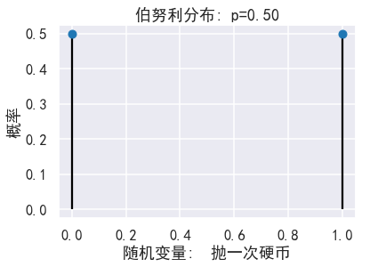

```python
"""
第三步，绘图
plot默认绘制折现
marker: 点的形状，值o代表为圆形标记（circle marker）
linestyle: 线条的形状，值None表示不显示连接各个点的折线
"""
plt.plot(X1, pList1, marker='o', linestyle='None')

"""
vlines用于绘制竖直线（vertical lines）
参数说明：vlines(x坐标，y坐标最小值，y坐标最大值)
我们传入的X是一个数组，是给数组中的每个x坐标值绘制竖直线，
竖直线的y坐标最小是0,ｙ坐标的最大值对应pList1中的值
"""
plt.vlines(X1, 0, pList1)
plt.xlabel("随机变量:　抛一次硬币")
plt.ylabel("概率")
plt.title("伯努利分布: p=%.2f" % p1)
plt.show()
```

# 二项分布

```python
# 第1步，定义随机变量：5次抛硬币，正面朝上的次数
n2 = 5    # 做某件事情的次数
p2 = 0.5  # 做某件事情成功的概率（抛硬币正面朝上的概率）
X2 = np.arange(0,n2+1,1) # 做某件事成功的次数（抛硬币正面朝上的次数）
X2
```

```
array([0, 1, 2, 3, 4, 5])
```

```python
# 第2步，求对应分布的概率：概率质量函数（PMF）
# 返回一个列表，列表中每个元素表示随机变量中对应值的概率
pList2 = stats.binom.pmf(X2,n2,p2)
pList2
```

```
array([0.03125, 0.15625, 0.3125 , 0.3125 , 0.15625, 0.03125])
```

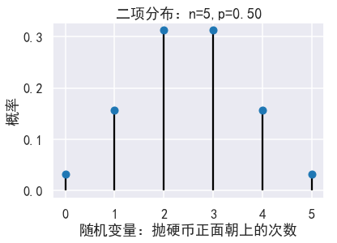

```python
"""
第3步，绘图
plot默认绘制折线
marker：点的形状，值o表示点为圆圈标记（circle marker）
linestyle：线条的形状，值None表示不显示连接各个点的折线
"""
plt.plot(X2,pList2,marker='o',linestyle='None')

"""
vlines用于绘制竖直线(vertical lines),
参数说明：vline(x坐标值, y坐标最小值, y坐标值最大值)
我们传入的X是一个数组，是给数组中的每个x坐标值绘制竖直线，
竖直线y坐标最小值是0，y坐标值最大值是对应pList2中的值
"""
plt.vlines(X2,0,pList2)
plt.xlabel('随机变量：抛硬币正面朝上的次数')
plt.ylabel('概率')
plt.title('二项分布：n=%i,p=%.2f' % (n2,p2))
plt.show()
```

# 几何分布

离散概率分布：几何分布（Geometric Distribution）  
几何分布就是在n次伯努利试验中，试验k次才得到第一次成功的机率。  
几何分布的特点：  
（1）进行一系列相互独立的试验；  
（2）每一次试验既有成功的可能，也有失败的可能，且单次试验的成功概率相同；  
（3）主要是为了取得第一次成功需要进行多少次试验。

```python
'''
第1步，定义随机变量：
首次表白成功的次数，可能是1次，2次，3次
'''
# 第k次做某件事，才取得第1次成功
# 这里我们想知道5次表白成功的概率
k = 5
# p3表示做某件事成功的概率，这里假设每次表白成功的概率为60%
p3 = 0.6
X3 = np.arange(1,k+1,1)
X3
```

```
array([1, 2, 3, 4, 5])
```

```python
'''
第2步，求对应分布的概率：概率质量函数（PMF）
返回一个列表，列表中每个元素表示随机变量中对应值的概率
分别表示第1次表白成功的概率，第2次表白成功的概率一直到第5次表白成功的概率
'''
pList3 = stats.geom.pmf(X3,p3)
pList3
```

```
array([0.6    , 0.24   , 0.096  , 0.0384 , 0.01536])
```

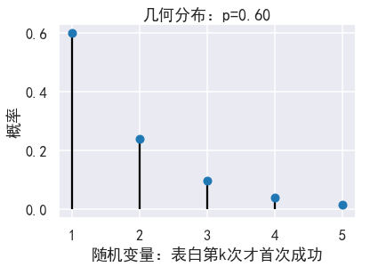

```python
'''
第3步，绘图
plot默认绘制折线
marker：点的形状，值o表示点为圆圈标记（circle marker）
linestyle：线条的形状，值None表示不显示连接各个点的折线
vlines用于绘制竖直线(vertical lines),
参数说明：vline(x坐标值, y坐标最小值, y坐标值最大值)
我们传入的X是一个数组，是给数组中的每个x坐标值绘制竖直线，
竖直线y坐标最小值是0，y坐标值最大值是对应pList中的值
'''
plt.plot(X3,pList3,marker='o',linestyle='None')
plt.vlines(X3,0,pList3)
plt.xlabel('随机变量：表白第k次才首次成功')
plt.ylabel('概率')
plt.title('几何分布：p=%.2f' % p3)
plt.show()
```

# 泊松分布

离散概率分布：泊松分布（Poisson Distribution）  
泊松分布描述的是已知一段时间内事件发生的平均数，求某个时间内发生的概率。  
泊松分布的特点：  
（1）单独事件在给定区间内随机、独立地发生，给定区间可以是时间或空间；  
（2）已知该区间内的事件平均发生次数（或叫做发生率），且为有限数值。该事件平均发生次数通常用希腊字母λ(lambda)表示。

```python
# 第1 步，定义随机变量
mu4 = 2  # 平均值：每天发生2次事故
k4 = 4   # 次数，现在想知道每天发生4次事故的概率
# 发生事故次数，包含0次，1次，2次，3次，4次事故
X4 = np.arange(0,k4+1,1)
X4
```

```
array([0, 1, 2, 3, 4])
```

```python
'''
第2步，求对应分布的概率：概率质量函数（PMF）
返回一个列表，列表中每个元素表示随机变量中对应值的概率
分别表示发生0次，1次，2次，3次，4次事故的概率
'''
pList4 = stats.poisson.pmf(X4,mu4)
pList4
```

```
array([0.13533528, 0.27067057, 0.27067057, 0.18044704, 0.09022352])
```

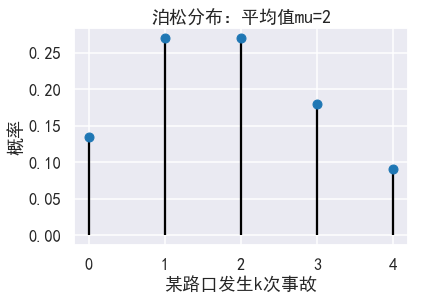

```python
# 第3步，绘图
plt.plot(X4,pList4,marker='o',linestyle='None')
plt.vlines(X4,0,pList4)
plt.xlabel('某路口发生k次事故')
plt.ylabel('概率')
plt.title('泊松分布：平均值mu=%i' % mu4 )
plt.show()
```

# 正态分布图

连续概率分布：正态分布（Normal Distribution）  
正态分布（Normal distribution），又名高斯分布（Gaussian distribution），正态曲线呈钟型，两头低，中间高，左右对称，中央部位的概率密度最大。越偏离均值，其概率密度减小。 若随机变量X服从一个数学期望为μ、方差为σ2的正态分布，记为N(μ，σ2)。其概率密度函数为正态分布的期望值μ决定了其位置，其标准差σ决定了分布的幅度。当μ = 0,σ = 1时的正态分布是标准正态分布。 概率密度函数f(x)：通过它可以求出一个数据范围内的某个连续变量的概率，可以指出该概率分布的形状。  
概率密度：通过面积指出各种范围内的概率大小，通过概率密度函数进行描述。  
求解正态分布概率步骤：  
（1）确定分布和范围，即算出均值和标准差；  
（2）将分布标准化，求出标准分；  
（3）查找概率，通过在概率表中查找标准分可以求出正态概率，概率表给出的是等于或小于这个数值的概率。

```python
# 第1步，定义随机变量
mu5 = 0   # 平均值
sigma = 1 # 标准差
X5 = np.arange(-5,5,0.1)
X5
```

[output not shown]

```python
# 第2步，求概率密度函数（PDF）
y = stats.norm.pdf(X5,mu5,sigma)
```

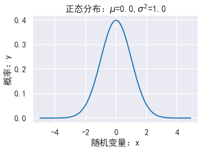

```python
# 第3步，绘图
plt.plot(X5,y)
plt.xlabel('随机变量：x')
plt.ylabel('概率：y')
plt.title('正态分布：$\mu$=%.1f,$\sigma^2$=%.1f' % (mu5,sigma))
plt.grid(True)
plt.show()
```